# Air Quality Index (AQI) Statistical Analysis - Pune

This notebook analyzes the Air Quality Index (AQI) dataset for Pune to apply various statistical techniques as required for the mini-project.

#### Installing dependencies

First, let's install the required packages for our analysis.

```python
%pip install -r requirements.txt
```

## 1. Loading and Exploring the Dataset

First, let's load the dataset and explore its structure. We're using a Pune Air Quality dataset with over 14,000 records, which meets our minimum requirement.

Dataset Columns:

- Date: The date of the recorded observation (non-null, string).
- SO2: Sulfur dioxide concentration (one missing value, string).
- NOx: Nitrogen oxides concentration (non-null, string).
- RSPM: Respirable suspended particulate matter (35 missing values, float).
- AQI: Air Quality Index (non-null, float).
- Area: Name of the area within Pune where the observation was recorded (non-null, string).

```python
# Import required libraries
import pandas as pd
import numpy as np
import matplotlib.pyplot as plt
import seaborn as sns
import scipy.stats as stats
from scipy.stats import zscore, ttest_ind, spearmanr
import plotly.express as px
import statsmodels.api as sm
import kagglehub

# Set up visualization style - Fix for the deprecated seaborn-whitegrid style
plt.style.use('seaborn-v0_8-whitegrid')  # Updated style name
sns.set_palette('viridis')
%matplotlib inline
plt.rcParams['figure.figsize'] = (12, 8)
```

```python
# Download the new dataset using kagglehub (with more records)
try:
    path = kagglehub.dataset_download("tejasnarkhede03/pune-air-quality-index")
    print(f"Dataset downloaded to: {path}")
except Exception as e:
    print(f"Error downloading dataset: {e}")
    print("If the automatic download fails, please download the dataset manually from Kaggle and place it in the project directory.")
```

```
Dataset downloaded to: /home/codespace/.cache/kagglehub/datasets/tejasnarkhede03/pune-air-quality-index/versions/1
```

```python
# Load the dataset
# Note: Adjust the file path if needed after downloading
import os
# Check what files are in the downloaded directory
if os.path.exists(path):
    print("Files in the dataset directory:")
    for file in os.listdir(path):
        print(f" - {file}")

# Load the CSV file (adjust filename if needed)
try:
    # Check for CSV files and load the first one
    csv_files = [f for f in os.listdir(path) if f.endswith('.csv')]
    if csv_files:
        file = csv_files[0]  # Choose the first CSV file
        df = pd.read_csv(os.path.join(path, file))
        print(f"Loaded dataset: {file}")
        print(f"Number of records: {len(df)}")
    else:
        print("No CSV files found in the dataset directory.")
except Exception as e:
    print(f"Error loading dataset: {e}")
```

```
Files in the dataset directory:
 - Pune Air Quality Index Dataset.csv
Loaded dataset: Pune Air Quality Index Dataset.csv
Number of records: 14873
```

```python
# Explore the dataset
print(f"Dataset shape: {df.shape}")
print(f"\nDataset info:")
df.info()
print(f"\nFirst 5 rows:")
df.head()
```

```
Dataset shape: (14873, 6)

Dataset info:
<class 'pandas.core.frame.DataFrame'>
RangeIndex: 14873 entries, 0 to 14872
Data columns (total 6 columns):
 #   Column  Non-Null Count  Dtype
---  ------  --------------  -----
 0   Date    14873 non-null  object
 1   SO2     14872 non-null  object
 2   NOx     14873 non-null  object
 3   RSPM    14838 non-null  float64
 4   AQI     14873 non-null  float64
 5   Area    14873 non-null  object
dtypes: float64(2), object(4)
memory usage: 697.3+ KB

First 5 rows:
```

|  | Date | SO2 | NOx | RSPM | AQI | Area |
| --- | --- | --- | --- | --- | --- | --- |
| 0 | 29-08-2005 | 20 | 38 | 84.0 | 84.0 | Pimpri-Chinchwad |
| 1 | 30-08-2005 | 21 | 43 | 94.0 | 94.0 | Pimpri-Chinchwad |
| 2 | 01-09-2005 | 17 | 35 | 74.0 | 74.0 | Pimpri-Chinchwad |
| 3 | 02-09-2005 | 15 | 28 | 68.0 | 68.0 | Pimpri-Chinchwad |
| 4 | 04-09-2005 | 17 | 31 | 72.0 | 72.0 | Pimpri-Chinchwad |

```python
# Check for and handle missing values
print("Missing values by column:")
print(df.isnull().sum())

# Convert string columns to numeric if they contain numeric data
# This dataset might have numeric values stored as strings
for col in df.columns:
    if df[col].dtype == 'object' and col != 'Date' and col != 'Area':
        try:
            # Try to convert to numeric, coercing errors to NaN
            df[col] = pd.to_numeric(df[col], errors='coerce')
            print(f"Converted {col} to numeric type")
        except Exception as e:
            print(f"Could not convert {col}: {e}")

# Handle missing values
df = df.dropna()
print(f"\nDataset shape after handling missing values: {df.shape}")
```

```
Missing values by column:
Date     0
SO2      1
NOx      0
RSPM    35
AQI      0
Area     0
dtype: int64
Converted SO2 to numeric type
Converted NOx to numeric type

Dataset shape after handling missing values: (14547, 6)
```

```python
# Fix Area names as requested
print("Unique areas before correction:")
print(df['Area'].unique())

# Replace 'Karvegar' with 'Karvenagar' and 'l Stop' with 'Other'
area_replacements = {
    'Karvegar': 'Karvenagar',
    'l Stop': 'Other'
}

df['Area'] = df['Area'].replace(area_replacements)

print("\nUnique areas after correction:")
print(df['Area'].unique())

# Count records by Area to verify changes
area_counts = df['Area'].value_counts()
print("\nRecords by Area:")
print(area_counts)
```

```
Unique areas before correction:
['Pimpri-Chinchwad' 'Karvegar' 'l Stop' 'Bhosari' 'Swargate']

Unique areas after correction:
['Pimpri-Chinchwad' 'Karvenagar' 'Other' 'Bhosari' 'Swargate']

Records by Area:
Area
Karvenagar          5043
Pimpri-Chinchwad    4666
Other               1687
Bhosari             1603
Swargate            1548
Name: count, dtype: int64
```

```python
# Data summary statistics
df.describe()
```

|  | SO2 | NOx | RSPM | AQI |
| --- | --- | --- | --- | --- |
| count | 14547.000000 | 14547.000000 | 14547.000000 | 14547.000000 |
| mean | 21.594006 | 50.940194 | 99.030865 | 98.011892 |
| std | 13.251183 | 29.370449 | 57.242143 | 46.078003 |
| min | 4.000000 | 9.000000 | 4.000000 | 11.000000 |
| 25% | 13.000000 | 32.000000 | 54.000000 | 63.000000 |
| 50% | 20.000000 | 46.000000 | 91.000000 | 96.000000 |
| 75% | 27.000000 | 64.000000 | 135.000000 | 127.000000 |
| max | 525.000000 | 896.000000 | 801.000000 | 864.000000 |

```python
# Add a date index for time-based analysis
try:
    # Convert the Date column to datetime
    df['Date'] = pd.to_datetime(df['Date'])

    # Extract year, month for additional analysis
    df['Year'] = df['Date'].dt.year
    df['Month'] = df['Date'].dt.month

    print("Date column successfully converted to datetime format")
    print(f"Date range: {df['Date'].min()} to {df['Date'].max()}")
except Exception as e:
    print(f"Error converting date: {e}")
```

[output not shown]

## 2. Central Limit Theorem Demonstration

The Central Limit Theorem (CLT) states that the sampling distribution of the mean approaches a normal distribution as the sample size gets larger, regardless of the population's distribution.

```
Demonstrating CLT using column: AQI
Sample Size 10:
Mean of sample means: 98.27
Standard deviation of sample means: 14.04
Expected standard error: 14.57

Sample Size 30:
Mean of sample means: 97.70
Standard deviation of sample means: 8.44
Expected standard error: 8.41

Sample Size 50:
Mean of sample means: 98.05
Standard deviation of sample means: 6.21
Expected standard error: 6.52
```

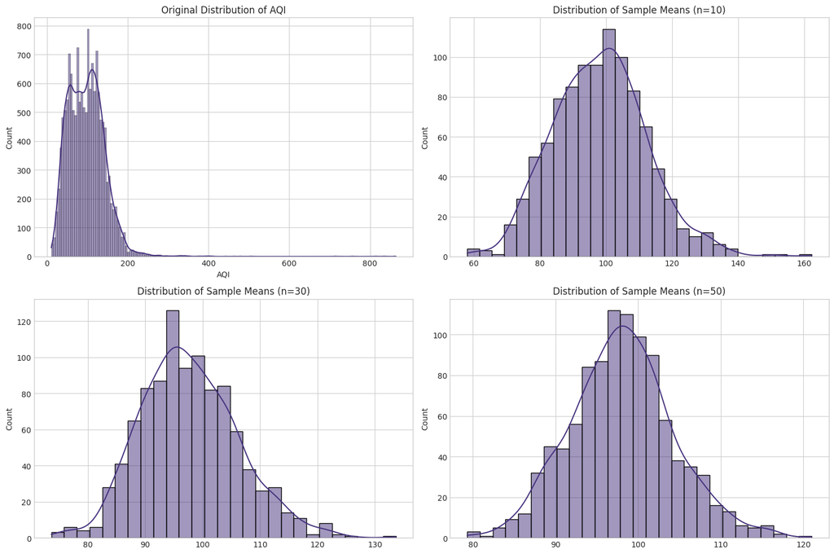

```python
# Select a numeric column for demonstration (AQI is a good candidate)
numeric_column = 'AQI'  # Using AQI column
print(f"Demonstrating CLT using column: {numeric_column}")

# Original distribution
plt.figure(figsize=(15, 10))
plt.subplot(2, 2, 1)
sns.histplot(df[numeric_column], kde=True)
plt.title(f'Original Distribution of {numeric_column}')

# Sample means for different sample sizes
sample_sizes = [10, 30, 50]
num_samples = 1000

for i, size in enumerate(sample_sizes):
    sample_means = [df[numeric_column].sample(size).mean() for _ in range(num_samples)]

    plt.subplot(2, 2, i+2)
    sns.histplot(sample_means, kde=True)
    plt.title(f'Distribution of Sample Means (n={size})')

    # Calculate and display statistics
    sample_mean = np.mean(sample_means)
    sample_std = np.std(sample_means)
    expected_std = df[numeric_column].std() / np.sqrt(size)  # Expected standard error

    print(f"Sample Size {size}:")
    print(f"Mean of sample means: {sample_mean:.2f}")
    print(f"Standard deviation of sample means: {sample_std:.2f}")
    print(f"Expected standard error: {expected_std:.2f}")
    print()

plt.tight_layout()
plt.show()
```

## 3. Mean Analysis

```
Analyzing numeric columns: ['SO2', 'NOx', 'RSPM', 'AQI']
Mean values for each parameter:
SO2     21.594006
NOx     50.940194
RSPM    99.030865
AQI     98.011892
dtype: float64
```

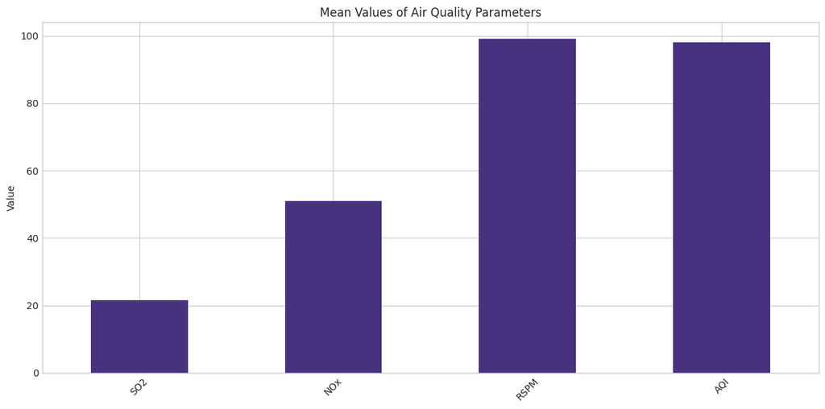

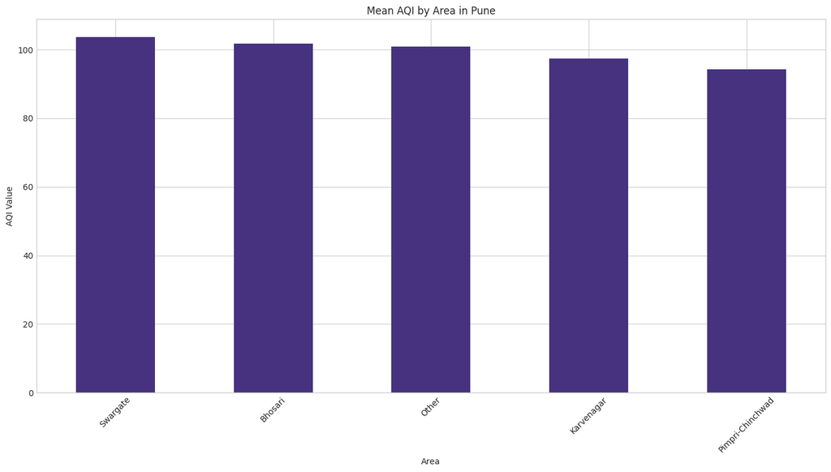

```python
# Select relevant numeric columns for analysis
numeric_cols = df.select_dtypes(include=np.number).columns.tolist()
# Remove Year and Month from numeric analysis if they exist
if 'Year' in numeric_cols:
    numeric_cols.remove('Year')
if 'Month' in numeric_cols:
    numeric_cols.remove('Month')

print(f"Analyzing numeric columns: {numeric_cols}")

# Mean values
means = df[numeric_cols].mean()
print("Mean values for each parameter:")
print(means)

# Visualize means
plt.figure(figsize=(12, 6))
means.plot(kind='bar')
plt.title('Mean Values of Air Quality Parameters')
plt.ylabel('Value')
plt.xticks(rotation=45)
plt.tight_layout()
plt.show()

# Mean AQI by area if 'Area' column exists
if 'Area' in df.columns:
    area_means = df.groupby('Area')['AQI'].mean().sort_values(ascending=False)
    plt.figure(figsize=(14, 8))
    area_means.plot(kind='bar')
    plt.title('Mean AQI by Area in Pune')
    plt.ylabel('AQI Value')
    plt.xlabel('Area')
    plt.xticks(rotation=45)
    plt.tight_layout()
    plt.show()
```

## 4. Variance and Standard Deviation

```
Variance for each parameter:
SO2      175.593854
NOx      862.623262
RSPM    3276.662941
AQI     2123.182383
dtype: float64

Standard Deviation for each parameter:
SO2     13.251183
NOx     29.370449
RSPM    57.242143
AQI     46.078003
dtype: float64
```

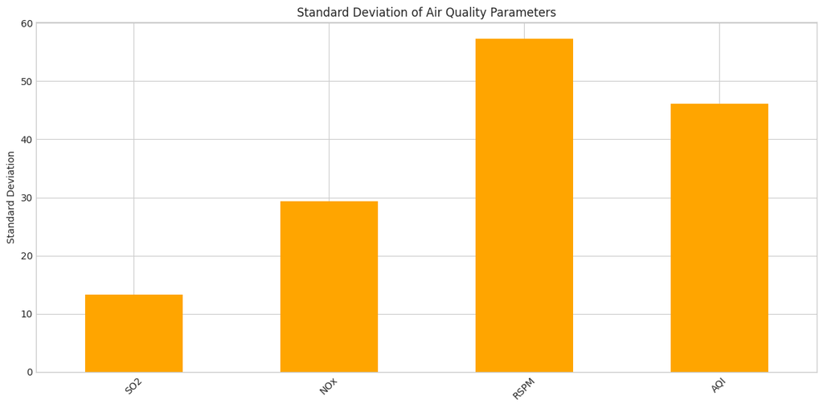

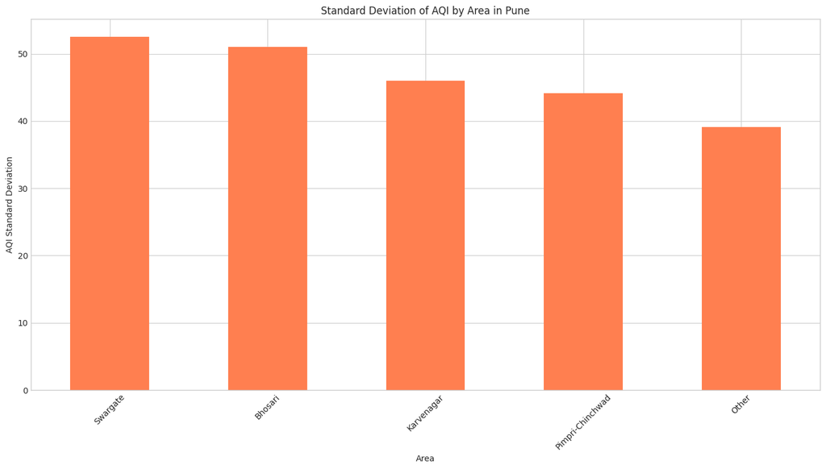

```python
# Calculate variance and standard deviation for each numeric column
variance = df[numeric_cols].var()
std_dev = df[numeric_cols].std()

# Display results
print("Variance for each parameter:")
print(variance)
print("\nStandard Deviation for each parameter:")
print(std_dev)

# Visualize standard deviation
plt.figure(figsize=(12, 6))
std_dev.plot(kind='bar', color='orange')
plt.title('Standard Deviation of Air Quality Parameters')
plt.ylabel('Standard Deviation')
plt.xticks(rotation=45)
plt.tight_layout()
plt.show()

# Standard deviation of AQI by area if 'Area' column exists
if 'Area' in df.columns:
    area_std = df.groupby('Area')['AQI'].std().sort_values(ascending=False)
    plt.figure(figsize=(14, 8))
    area_std.plot(kind='bar', color='coral')
    plt.title('Standard Deviation of AQI by Area in Pune')
    plt.ylabel('AQI Standard Deviation')
    plt.xlabel('Area')
    plt.xticks(rotation=45)
    plt.tight_layout()
    plt.show()
```

## 5. Quartile Analysis (Q1, Q2, Q3)

```
First Quartile (Q1, 25%):
SO2     13.0
NOx     32.0
RSPM    54.0
AQI     63.0
Name: 0.25, dtype: float64

Second Quartile (Q2, 50%, Median):
SO2     20.0
NOx     46.0
RSPM    91.0
AQI     96.0
Name: 0.5, dtype: float64

Third Quartile (Q3, 75%):
SO2      27.0
NOx      64.0
RSPM    135.0
AQI     127.0
Name: 0.75, dtype: float64
```

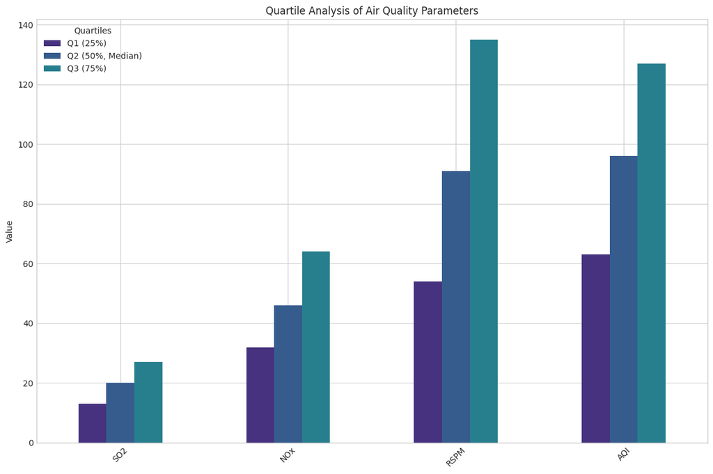

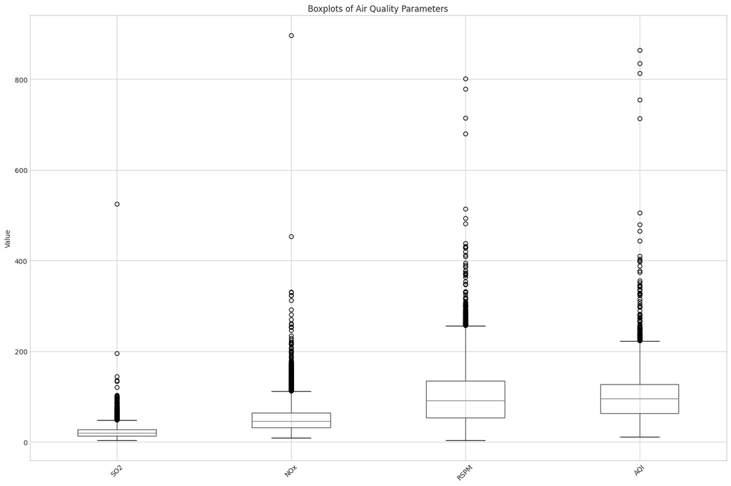

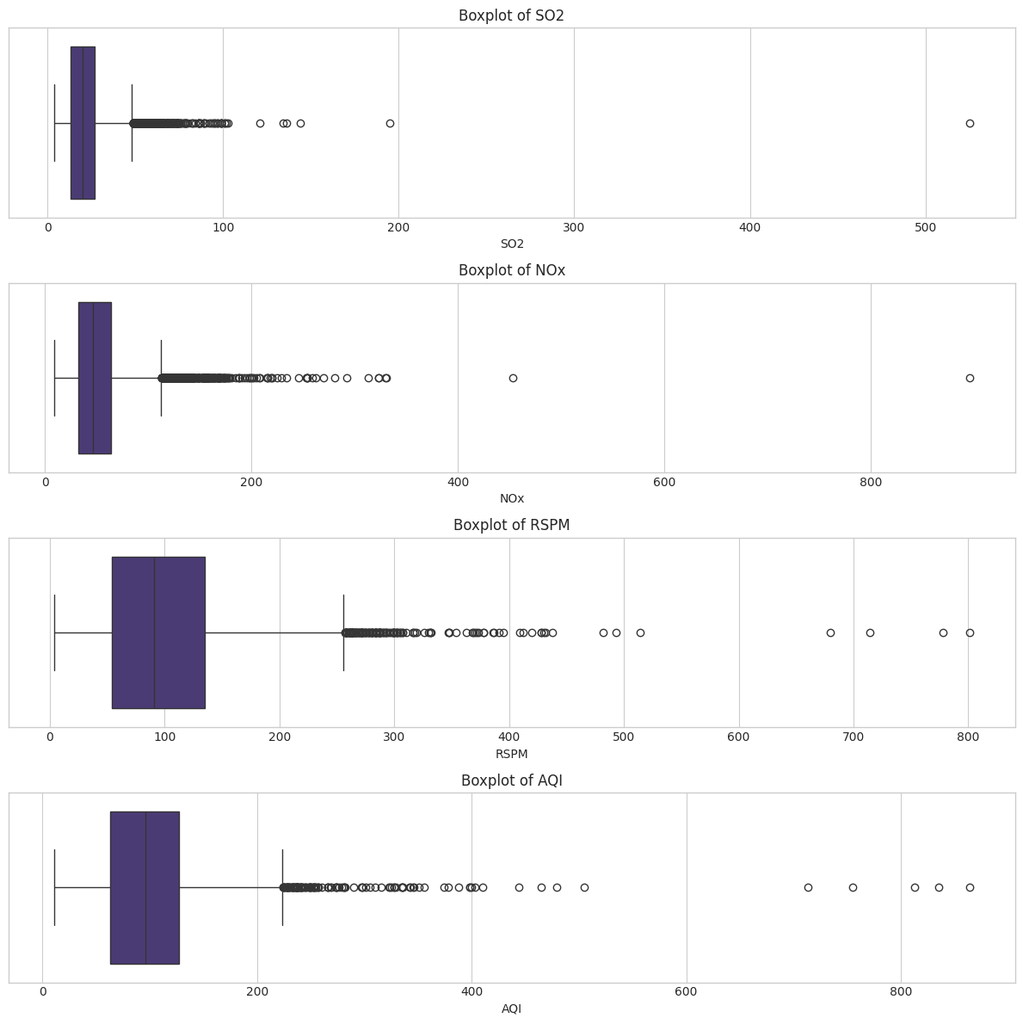

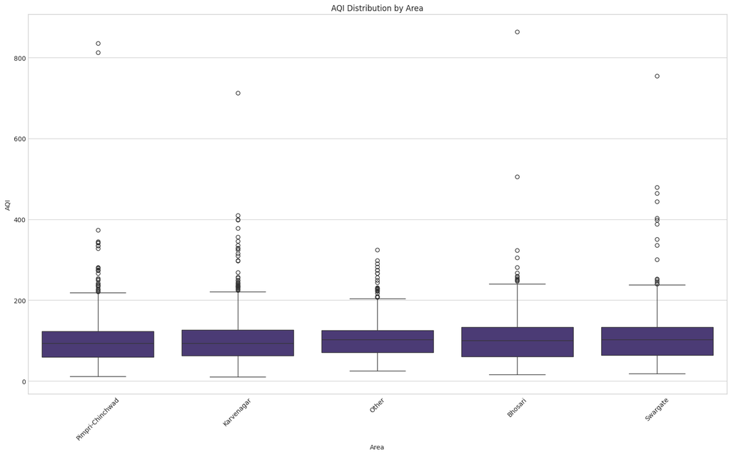

```python
# Calculate quartiles
q1 = df[numeric_cols].quantile(0.25)
q2 = df[numeric_cols].quantile(0.50)  # Median
q3 = df[numeric_cols].quantile(0.75)

# Display results
print("First Quartile (Q1, 25%):")
print(q1)
print("\nSecond Quartile (Q2, 50%, Median):")
print(q2)
print("\nThird Quartile (Q3, 75%):")
print(q3)

# Create a DataFrame for quartile visualization
quartiles_df = pd.DataFrame({
    'Q1 (25%)': q1,
    'Q2 (50%, Median)': q2,
    'Q3 (75%)': q3
})

# Plot quartiles for each parameter
plt.figure(figsize=(14, 8))
quartiles_df.plot(kind='bar')
plt.title('Quartile Analysis of Air Quality Parameters')
plt.ylabel('Value')
plt.legend(title='Quartiles')
plt.xticks(rotation=45)
plt.tight_layout()
plt.show()

# Create boxplots for each numeric parameter
plt.figure(figsize=(15, 10))
df[numeric_cols].boxplot()
plt.title('Boxplots of Air Quality Parameters')
plt.ylabel('Value')
plt.xticks(rotation=45)
plt.tight_layout()
plt.show()

# Create individual boxplots for better visualization
fig, axes = plt.subplots(nrows=len(numeric_cols), figsize=(12, 3*len(numeric_cols)))
for i, col in enumerate(numeric_cols):
    sns.boxplot(x=df[col], ax=axes[i])
    axes[i].set_title(f'Boxplot of {col}')
plt.tight_layout()
plt.show()

# Boxplot of AQI by area if 'Area' column exists
if 'Area' in df.columns:
    plt.figure(figsize=(16, 10))
    sns.boxplot(x='Area', y='AQI', data=df)
    plt.title('AQI Distribution by Area')
    plt.xticks(rotation=45)
    plt.tight_layout()
    plt.show()
```

## 6. Weighted Mean

For weighted mean, we need to determine appropriate weights for each observation. For air quality data, we might weight measurements based on factors like:

- Time of day (peak hours might be more relevant)
- Season (seasonal variations)
- Location importance

Let's create a few weighted mean scenarios:

```python
# Example 1: Weight by inverse of standard deviation
# (giving more weight to more consistent measurements)
weights_by_consistency = 1 / (df[numeric_cols].std() + 0.0001)  # Adding small constant to avoid division by zero
weights_by_consistency = weights_by_consistency / weights_by_consistency.sum()  # Normalize

weighted_mean_consistency = (df[numeric_cols].mean() * weights_by_consistency).sum()
print(f"Weighted mean (by consistency) across all parameters: {weighted_mean_consistency:.2f}")

# Example 2: Weight by season (if we have date information)
if 'Month' in df.columns:
    # Define season weights - giving more weight to winter months when pollution is typically higher
    winter_months = [11, 12, 1, 2]  # Nov, Dec, Jan, Feb
    df['season_weight'] = df['Month'].apply(lambda x: 2 if x in winter_months else 1)

    # Calculate weighted mean for AQI by season
    weighted_mean_season = np.average(df['AQI'], weights=df['season_weight'])
    regular_mean = df['AQI'].mean()

    print(f"Regular mean for AQI: {regular_mean:.2f}")
    print(f"Weighted mean (by season) for AQI: {weighted_mean_season:.2f}")
    print(f"Difference: {weighted_mean_season - regular_mean:.2f} ({((weighted_mean_season - regular_mean)/regular_mean)*100:.2f}%)")

# Example 3: Weight by area importance (if 'Area' column exists)
if 'Area' in df.columns:
    # First, get the population density or importance of each area
    # For this example, we'll use the area's average AQI as a proxy for importance
    area_importance = df.groupby('Area')['AQI'].mean()

    # Create a dictionary mapping areas to their weights
    area_weights = {area: importance / area_importance.min() for area, importance in area_importance.items()}

    # Apply weights to each observation based on its area
    df['area_weight'] = df['Area'].map(area_weights)

    # Calculate weighted mean for each numeric column
    weighted_means_by_area = {}
    for col in numeric_cols:
        if col != 'area_weight':
            regular_mean = df[col].mean()
            weighted_mean = np.average(df[col], weights=df['area_weight'])
            weighted_means_by_area[col] = (regular_mean, weighted_mean)

    # Display results
    print("\nWeighted means by area importance:")
    for col, (reg_mean, weighted_mean) in weighted_means_by_area.items():
        print(f"{col}: Regular mean = {reg_mean:.2f}, Weighted mean = {weighted_mean:.2f}, Diff = {weighted_mean - reg_mean:.2f}")
else:
    # Simulate with random weights if area data not available
    print("\nSimulating area-based weighting (since Area column not found):")
    np.random.seed(42)  # For reproducibility
    random_weights = np.random.randint(1, 4, size=len(df))

    for col in numeric_cols[:3]:  # Show for first 3 numeric columns
        regular_mean = df[col].mean()
        weighted_mean = np.average(df[col], weights=random_weights)
        print(f"{col}: Regular mean = {regular_mean:.2f}, Weighted mean = {weighted_mean:.2f}, Diff = {weighted_mean - regular_mean:.2f}")
```

```
Weighted mean (by consistency) across all parameters: 48.57
Regular mean for AQI: 98.01
Weighted mean (by season) for AQI: 105.28
Difference: 7.27 (7.42%)

Weighted means by area importance:
SO2: Regular mean = 21.59, Weighted mean = 21.60, Diff = 0.00
NOx: Regular mean = 50.94, Weighted mean = 50.99, Diff = 0.05
RSPM: Regular mean = 99.03, Weighted mean = 99.17, Diff = 0.14
AQI: Regular mean = 98.01, Weighted mean = 98.12, Diff = 0.11
```

## 7. Coefficient of Variation

The coefficient of variation (CV) is the ratio of the standard deviation to the mean. It shows the extent of variability in relation to the mean.

```
Coefficient of Variation (%) for each parameter:
SO2     61.365100
NOx     57.656728
RSPM    57.802325
AQI     47.012666
dtype: float64
```

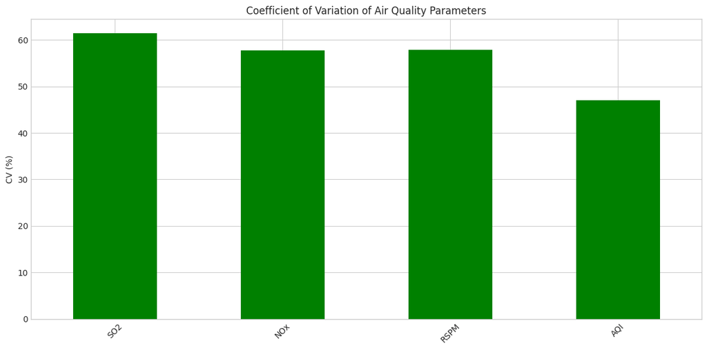

```
Interpretation:
Parameters with high variability (CV > 50%): SO2, NOx, RSPM
Parameters with medium variability (20% < CV ≤ 50%): AQI
```

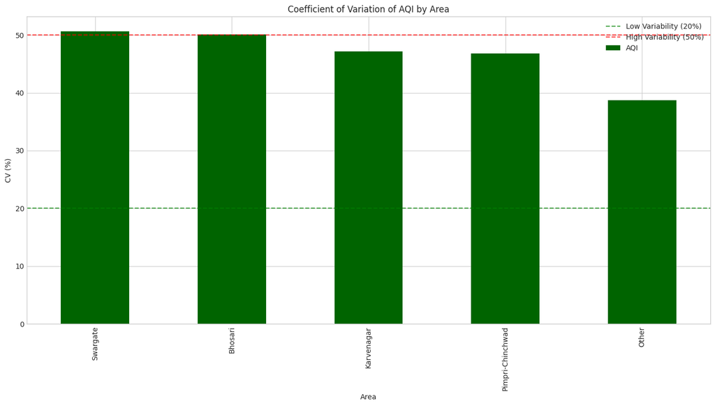

```python
# Calculate coefficient of variation for each numeric parameter
cv = (std_dev / means) * 100  # Expressed as percentage

print("Coefficient of Variation (%) for each parameter:")
print(cv)

# Visualize coefficient of variation
plt.figure(figsize=(12, 6))
cv.plot(kind='bar', color='green')
plt.title('Coefficient of Variation of Air Quality Parameters')
plt.ylabel('CV (%)')
plt.xticks(rotation=45)
plt.tight_layout()
plt.show()

# Interpretation
high_cv_params = cv[cv > 50].index.tolist()  # Parameters with CV > 50%
medium_cv_params = cv[(cv > 20) & (cv <= 50)].index.tolist()  # Parameters with CV between 20% and 50%
low_cv_params = cv[cv <= 20].index.tolist()   # Parameters with CV <= 20%

print("\nInterpretation:")
if high_cv_params:
    print(f"Parameters with high variability (CV > 50%): {', '.join(high_cv_params)}")
if medium_cv_params:
    print(f"Parameters with medium variability (20% < CV ≤ 50%): {', '.join(medium_cv_params)}")
if low_cv_params:
    print(f"Parameters with low variability (CV ≤ 20%): {', '.join(low_cv_params)}")

# CV by area if 'Area' column exists
if 'Area' in df.columns:
    area_means = df.groupby('Area')['AQI'].mean()
    area_stds = df.groupby('Area')['AQI'].std()
    area_cv = (area_stds / area_means) * 100

    plt.figure(figsize=(14, 8))
    area_cv.sort_values(ascending=False).plot(kind='bar', color='darkgreen')
    plt.title('Coefficient of Variation of AQI by Area')
    plt.ylabel('CV (%)')
    plt.axhline(y=20, color='green', linestyle='--', alpha=0.7, label='Low Variability (20%)')
    plt.axhline(y=50, color='red', linestyle='--', alpha=0.7, label='High Variability (50%)')
    plt.legend()
    plt.tight_layout()
    plt.show()
```

## 8. Correlation Analysis

```
Correlation Matrix:
           SO2       NOx      RSPM       AQI
SO2   1.000000  0.233369  0.185079  0.227251
NOx   0.233369  1.000000  0.348842  0.575189
RSPM  0.185079  0.348842  1.000000  0.917112
AQI   0.227251  0.575189  0.917112  1.000000
```

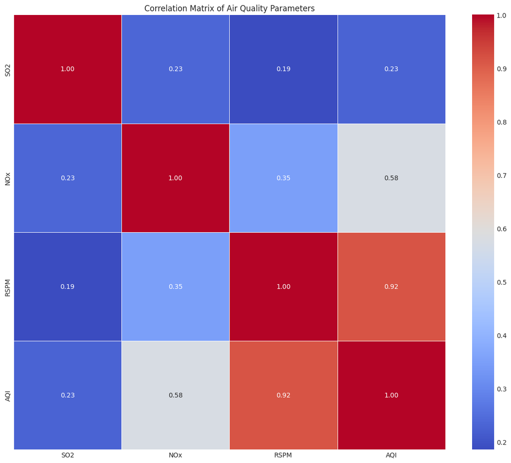

```
Top 5 strongest correlations:
RSPM and AQI: 0.9171
NOx and AQI: 0.5752
NOx and RSPM: 0.3488
SO2 and NOx: 0.2334
SO2 and AQI: 0.2273
```

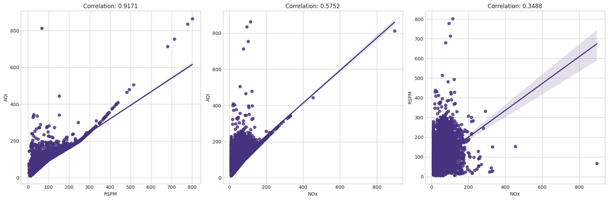

```python
# Calculate the correlation matrix
correlation_matrix = df[numeric_cols].corr()

# Display the correlation matrix
print("Correlation Matrix:")
print(correlation_matrix)

# Visualize the correlation matrix as a heatmap
plt.figure(figsize=(12, 10))
sns.heatmap(correlation_matrix, annot=True, cmap='coolwarm', linewidths=0.5, fmt='.2f')
plt.title('Correlation Matrix of Air Quality Parameters')
plt.tight_layout()
plt.show()

# Find the strongest positive and negative correlations
# Excluding self-correlations (which are always 1)
corr_pairs = []
for i in range(len(numeric_cols)):
    for j in range(i+1, len(numeric_cols)):
        corr_pairs.append((numeric_cols[i], numeric_cols[j], correlation_matrix.iloc[i, j]))

# Sort by absolute correlation value
corr_pairs.sort(key=lambda x: abs(x[2]), reverse=True)

print("\nTop 5 strongest correlations:")
for param1, param2, corr in corr_pairs[:5]:
    print(f"{param1} and {param2}: {corr:.4f}")

# Visualize the top 3 correlations as scatter plots with regression line
if len(corr_pairs) >= 3:
    fig, axes = plt.subplots(1, min(3, len(corr_pairs)), figsize=(18, 6))
    for i, (param1, param2, corr) in enumerate(corr_pairs[:min(3, len(corr_pairs))]):
        if len(corr_pairs) == 1:  # Handle case with only one correlation pair
            ax = axes
        else:
            ax = axes[i]
        sns.regplot(x=df[param1], y=df[param2], ax=ax)
        ax.set_title(f'Correlation: {corr:.4f}')
        ax.set_xlabel(param1)
        ax.set_ylabel(param2)
    plt.tight_layout()
    plt.show()
```

## 9. Regression Lines (Y on X and X on Y)

```
Analyzing regression between RSPM and AQI (correlation: 0.9171)
Y on X Regression Summary:
                            OLS Regression Results
==============================================================================
Dep. Variable:                    AQI   R-squared:                       0.841
Model:                            OLS   Adj. R-squared:                  0.841
Method:                 Least Squares   F-statistic:                 7.699e+04
Date:                Sat, 26 Apr 2025   Prob (F-statistic):               0.00
Time:                        07:36:56   Log-Likelihood:                -62981.
No. Observations:               14547   AIC:                         1.260e+05
Df Residuals:                   14545   BIC:                         1.260e+05
Df Model:                           1
Covariance Type:            nonrobust
==============================================================================
                 coef    std err          t      P>|t|      [0.025      0.975]
------------------------------------------------------------------------------
const         24.9029      0.304     81.827      0.000      24.306      25.499
RSPM           0.7382      0.003    277.466      0.000       0.733       0.743
==============================================================================
Omnibus:                    22791.910   Durbin-Watson:                   0.969
Prob(Omnibus):                  0.000   Jarque-Bera (JB):         32134057.004
Skew:                           9.655   Prob(JB):                         0.00
Kurtosis:                     232.440   Cond. No.                         229.
==============================================================================

Notes:
[1] Standard Errors assume that the covariance matrix of the errors is correctly specified.

X on Y Regression Summary:
                            OLS Regression Results
==============================================================================
Dep. Variable:                   RSPM   R-squared:                       0.841
Model:                            OLS   Adj. R-squared:                  0.841
Method:                 Least Squares   F-statistic:                 7.699e+04
Date:                Sat, 26 Apr 2025   Prob (F-statistic):               0.00
Time:                        07:36:56   Log-Likelihood:                -66138.
No. Observations:               14547   AIC:                         1.323e+05
Df Residuals:                   14545   BIC:                         1.323e+05
Df Model:                           1
Covariance Type:            nonrobust
==============================================================================
                 coef    std err          t      P>|t|      [0.025      0.975]
------------------------------------------------------------------------------
const        -12.6358      0.445    -28.414      0.000     -13.507     -11.764
AQI            1.1393      0.004    277.466      0.000       1.131       1.147
==============================================================================
Omnibus:                    20267.569   Durbin-Watson:                   0.871
Prob(Omnibus):                  0.000   Jarque-Bera (JB):         16817095.764
Skew:                          -7.721   Prob(JB):                         0.00
Kurtosis:                     168.852   Cond. No.                         255.
==============================================================================

Notes:
[1] Standard Errors assume that the covariance matrix of the errors is correctly specified.
```

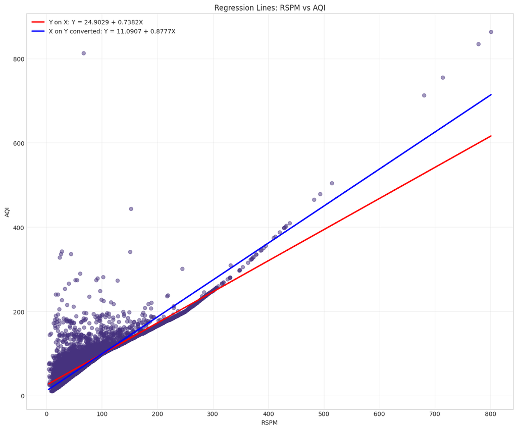

```
R-squared for Y on X: 0.8411
R-squared for X on Y: 0.8411
```

```python
# Select the two parameters with the highest correlation
if len(corr_pairs) > 0:
    param1, param2, corr_value = corr_pairs[0]  # Strongest correlation pair
    print(f"Analyzing regression between {param1} and {param2} (correlation: {corr_value:.4f})")

    # Linear regression Y on X
    x = df[param1]
    y = df[param2]

    # Add constant for intercept
    X = sm.add_constant(x)

    # Y on X regression
    model_y_on_x = sm.OLS(y, X).fit()
    print("Y on X Regression Summary:")
    print(model_y_on_x.summary())

    # X on Y regression
    Y = sm.add_constant(y)
    model_x_on_y = sm.OLS(x, Y).fit()
    print("\nX on Y Regression Summary:")
    print(model_x_on_y.summary())

    # Get coefficients for both models
    slope_y_on_x = model_y_on_x.params[1]
    intercept_y_on_x = model_y_on_x.params[0]

    slope_x_on_y = model_x_on_y.params[1]
    intercept_x_on_y = model_x_on_y.params[0]

    # Calculate predicted values
    y_pred = intercept_y_on_x + slope_y_on_x * x
    x_pred = intercept_x_on_y + slope_x_on_y * y

    # Visualize both regression lines
    plt.figure(figsize=(12, 10))

    # Scatter plot
    plt.scatter(x, y, alpha=0.5)

    # Y on X regression line
    plt.plot(x, y_pred, color='red', linewidth=2, label=f'Y on X: Y = {intercept_y_on_x:.4f} + {slope_y_on_x:.4f}X')

    # X on Y regression line (need to convert to Y = f(X) form for plotting)
    # X = a + bY => Y = (X - a)/b
    inverse_slope = 1/slope_x_on_y
    inverse_intercept = -intercept_x_on_y/slope_x_on_y
    plt.plot(x, (x - intercept_x_on_y) / slope_x_on_y, color='blue', linewidth=2,
             label=f'X on Y converted: Y = {inverse_intercept:.4f} + {inverse_slope:.4f}X')

    plt.xlabel(param1)
    plt.ylabel(param2)
    plt.title(f'Regression Lines: {param1} vs {param2}')
    plt.legend()
    plt.grid(True, alpha=0.3)
    plt.tight_layout()
    plt.show()

    # Calculate and display R-squared values
    r_squared_y_on_x = model_y_on_x.rsquared
    r_squared_x_on_y = model_x_on_y.rsquared

    print(f"\nR-squared for Y on X: {r_squared_y_on_x:.4f}")
    print(f"R-squared for X on Y: {r_squared_x_on_y:.4f}")
else:
    print("Not enough numeric columns to perform regression analysis")
```

## 10. Rank Correlation

```
Spearman Rank Correlation Matrix:
           SO2       NOx      RSPM       AQI
SO2   1.000000  0.329909  0.235825  0.276374
NOx   0.329909  1.000000  0.424851  0.575420
RSPM  0.235825  0.424851  1.000000  0.931279
AQI   0.276374  0.575420  0.931279  1.000000
```

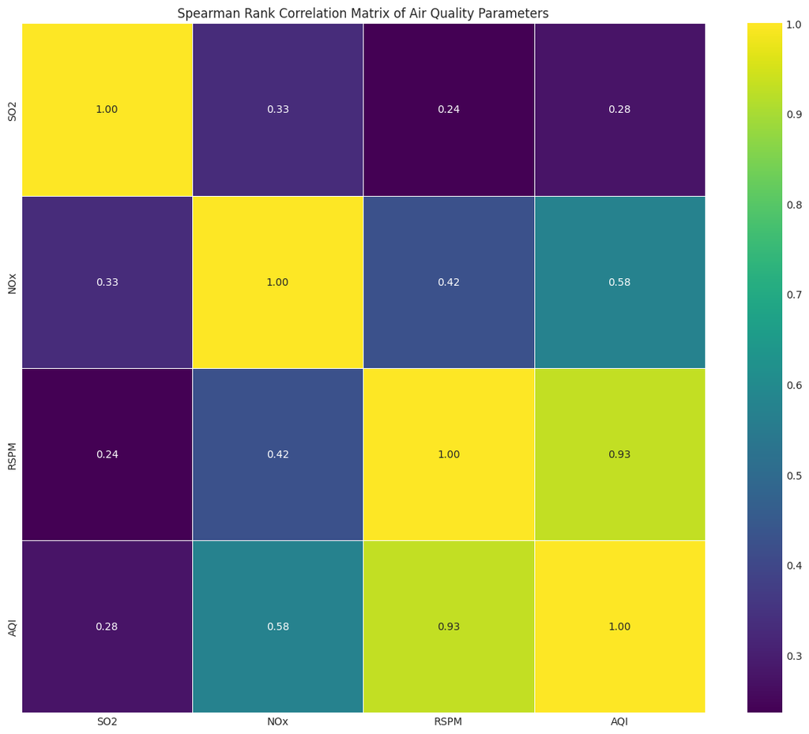

```
Comparing Pearson vs Spearman correlation for top pairs:
RSPM and AQI: Pearson = 0.9171, Spearman = 0.9313, Difference = 0.0142
NOx and AQI: Pearson = 0.5752, Spearman = 0.5754, Difference = 0.0002
NOx and RSPM: Pearson = 0.3488, Spearman = 0.4249, Difference = 0.0760
SO2 and NOx: Pearson = 0.2334, Spearman = 0.3299, Difference = 0.0965
SO2 and AQI: Pearson = 0.2273, Spearman = 0.2764, Difference = 0.0491

Top pairs with largest difference between Pearson and Spearman:
SO2 and NOx: Pearson = 0.2334, Spearman = 0.3299, Difference = 0.0965
```

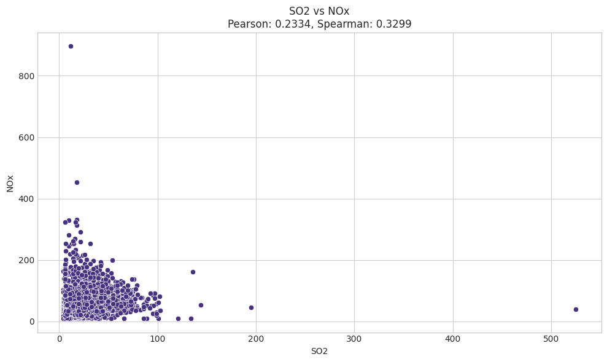

```
NOx and RSPM: Pearson = 0.3488, Spearman = 0.4249, Difference = 0.0760
```

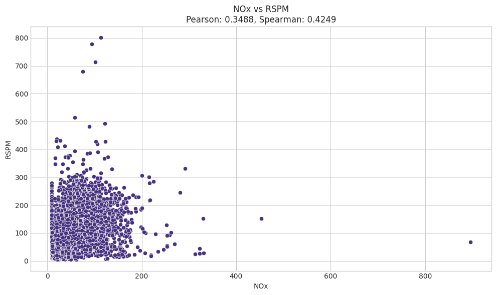

```
SO2 and RSPM: Pearson = 0.1851, Spearman = 0.2358, Difference = 0.0507
```

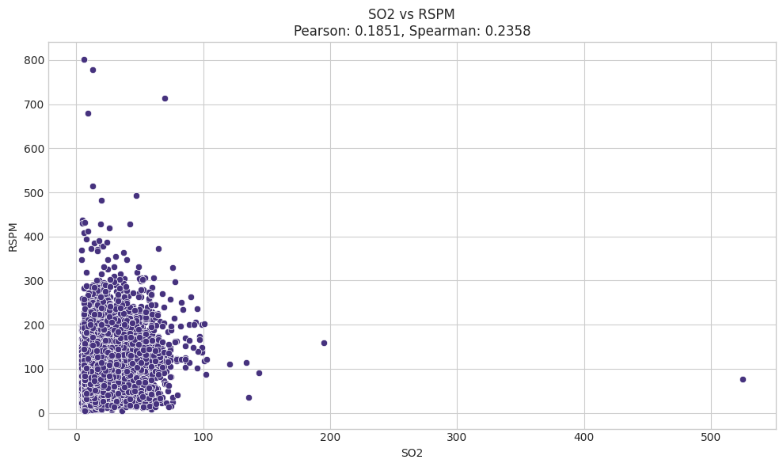

```python
# Calculate Spearman's rank correlation coefficient matrix
spearman_corr = df[numeric_cols].corr(method='spearman')

# Display the Spearman correlation matrix
print("Spearman Rank Correlation Matrix:")
print(spearman_corr)

# Visualize the Spearman correlation matrix
plt.figure(figsize=(12, 10))
sns.heatmap(spearman_corr, annot=True, cmap='viridis', linewidths=0.5, fmt='.2f')
plt.title('Spearman Rank Correlation Matrix of Air Quality Parameters')
plt.tight_layout()
plt.show()

if len(corr_pairs) > 0:
    # Compare Pearson vs Spearman correlation for top pairs
    print("\nComparing Pearson vs Spearman correlation for top pairs:")
    for param1, param2, pearson_corr in corr_pairs[:min(5, len(corr_pairs))]:  # Top 5 from Pearson (or less if fewer pairs)
        spearman = spearman_corr.loc[param1, param2]
        print(f"{param1} and {param2}: Pearson = {pearson_corr:.4f}, Spearman = {spearman:.4f}, Difference = {abs(pearson_corr - spearman):.4f}")

    # Find pairs with large differences between Pearson and Spearman
    diff_pairs = []
    for i in range(len(numeric_cols)):
        for j in range(i+1, len(numeric_cols)):
            param1, param2 = numeric_cols[i], numeric_cols[j]
            pearson = correlation_matrix.iloc[i, j]
            spearman = spearman_corr.iloc[i, j]
            diff = abs(pearson - spearman)
            diff_pairs.append((param1, param2, pearson, spearman, diff))

    diff_pairs.sort(key=lambda x: x[4], reverse=True)  # Sort by difference

    print("\nTop pairs with largest difference between Pearson and Spearman:")
    for param1, param2, pearson, spearman, diff in diff_pairs[:min(3, len(diff_pairs))]:
        print(f"{param1} and {param2}: Pearson = {pearson:.4f}, Spearman = {spearman:.4f}, Difference = {diff:.4f}")

        # Visualize the pair with scatter plot
        plt.figure(figsize=(10, 6))
        sns.scatterplot(x=df[param1], y=df[param2])
        plt.title(f'{param1} vs {param2}\nPearson: {pearson:.4f}, Spearman: {spearman:.4f}')
        plt.xlabel(param1)
        plt.ylabel(param2)
        plt.tight_layout()
        plt.show()
```

## 11. Hypothesis Testing (Z-test and T-test)

Let's perform hypothesis tests on our AQI data:

```
Z-test for AQI:
Sample mean: 98.0119
Hypothesized value: 88.2107
Z-statistic: 25.6550
P-value: 0.00000000
Conclusion: Reject null hypothesis at 5% significance level.

T-test comparing two groups:

Comparing AQI by season:
Winter months: n=4883, mean=126.9322
Summer months: n=4731, mean=80.0194
t-statistic: 56.7010
P-value: 0.00000000
Conclusion: Reject null hypothesis at 5% significance level.
```

[figure not shown]

```
Comparing AQI between two areas:
Area 1 (Karvenagar): n=5043, mean=97.4959
Area 2 (Pimpri-Chinchwad): n=4666, mean=94.3260
t-statistic: 3.4678
P-value: 0.00052710
Conclusion: Reject null hypothesis at 5% significance level.
```

[figure not shown]

```
Generic t-test comparing two groups:
Splitting data by median of SO2 (20.0000)
Group 1 (≤ median): n=7830, mean=89.0991
Group 2 (> median): n=6717, mean=108.4015
t-statistic: -26.0721
P-value: 0.00000000
Conclusion: Reject null hypothesis at 5% significance level.
```

[figure not shown]

```python
# Z-test example: Compare AQI mean to a hypothesized value
# Z-test uses known population std dev, but we'll use sample std dev since we don't have population std dev
test_param = 'AQI'  # Using AQI for hypothesis tests

# Define hypothesized value based on WHO or national AQI standard
# For demonstration, we'll use a hypothesized value that's 90% of the mean
hypothesized_value = df[test_param].mean() * 0.9

print(f"Z-test for {test_param}:")
print(f"Sample mean: {df[test_param].mean():.4f}")
print(f"Hypothesized value: {hypothesized_value:.4f}")

# Calculate Z-statistic
sample_mean = df[test_param].mean()
sample_std = df[test_param].std()
sample_size = len(df)
std_error = sample_std / np.sqrt(sample_size)

z_statistic = (sample_mean - hypothesized_value) / std_error
p_value = 2 * (1 - stats.norm.cdf(abs(z_statistic)))  # Two-tailed test

print(f"Z-statistic: {z_statistic:.4f}")
print(f"P-value: {p_value:.8f}")
print(f"Conclusion: {'Reject' if p_value < 0.05 else 'Fail to reject'} null hypothesis at 5% significance level.")

# T-test example: Compare AQI between two different conditions
print("\nT-test comparing two groups:")

# We could split the data in various ways - by area, by season, etc.
# Let's try a few different approaches based on available data

# Option 1: Split by season if we have Month information
if 'Month' in df.columns:
    print("\nComparing AQI by season:")
    # Define winter and summer months
    winter_months = [11, 12, 1, 2]  # Nov, Dec, Jan, Feb
    summer_months = [4, 5, 6, 7]    # Apr, May, Jun, Jul

    winter_aqi = df[df['Month'].isin(winter_months)][test_param]
    summer_aqi = df[df['Month'].isin(summer_months)][test_param]

    print(f"Winter months: n={len(winter_aqi)}, mean={winter_aqi.mean():.4f}")
    print(f"Summer months: n={len(summer_aqi)}, mean={summer_aqi.mean():.4f}")

    # Perform t-test
    t_statistic, p_value = ttest_ind(winter_aqi, summer_aqi, equal_var=False)  # Welch's t-test

    print(f"t-statistic: {t_statistic:.4f}")
    print(f"P-value: {p_value:.8f}")
    print(f"Conclusion: {'Reject' if p_value < 0.05 else 'Fail to reject'} null hypothesis at 5% significance level.")

    # Visualize the comparison
    plt.figure(figsize=(12, 6))
    sns.boxplot(data=[winter_aqi, summer_aqi])
    plt.xticks([0, 1], ['Winter', 'Summer'])
    plt.ylabel(test_param)
    plt.title(f'Comparison of {test_param} by Season\nt={t_statistic:.2f}, p={p_value:.4f}')
    plt.tight_layout()
    plt.show()

# Option 2: Split by area if we have Area information
if 'Area' in df.columns and len(df['Area'].unique()) >= 2:
    print("\nComparing AQI between two areas:")
    areas = df['Area'].unique()
    # Select the two areas with the most data points
    area_counts = df['Area'].value_counts()
    area1, area2 = area_counts.index[:2]

    area1_aqi = df[df['Area'] == area1][test_param]
    area2_aqi = df[df['Area'] == area2][test_param]

    print(f"Area 1 ({area1}): n={len(area1_aqi)}, mean={area1_aqi.mean():.4f}")
    print(f"Area 2 ({area2}): n={len(area2_aqi)}, mean={area2_aqi.mean():.4f}")

    # Perform t-test
    t_statistic, p_value = ttest_ind(area1_aqi, area2_aqi, equal_var=False)  # Welch's t-test

    print(f"t-statistic: {t_statistic:.4f}")
    print(f"P-value: {p_value:.8f}")
    print(f"Conclusion: {'Reject' if p_value < 0.05 else 'Fail to reject'} null hypothesis at 5% significance level.")

    # Visualize the comparison
    plt.figure(figsize=(12, 6))
    sns.boxplot(data=[area1_aqi, area2_aqi])
    plt.xticks([0, 1], [area1, area2])
    plt.ylabel(test_param)
    plt.title(f'Comparison of {test_param} by Area\nt={t_statistic:.2f}, p={p_value:.4f}')
    plt.tight_layout()
    plt.show()

# Option 3: Generic split by median of another parameter (fallback if neither area nor month are available)
if len(numeric_cols) > 1:
    print("\nGeneric t-test comparing two groups:")
    # Find a parameter other than AQI
    other_params = [col for col in numeric_cols if col != test_param][:1]  # Take first available

    if other_params:
        split_param = other_params[0]
        median_value = df[split_param].median()

        group1 = df[df[split_param] <= median_value][test_param]
        group2 = df[df[split_param] > median_value][test_param]

        print(f"Splitting data by median of {split_param} ({median_value:.4f})")
        print(f"Group 1 (≤ median): n={len(group1)}, mean={group1.mean():.4f}")
        print(f"Group 2 (> median): n={len(group2)}, mean={group2.mean():.4f}")

        # Perform t-test
        t_statistic, p_value = ttest_ind(group1, group2, equal_var=False)  # Welch's t-test

        print(f"t-statistic: {t_statistic:.4f}")
        print(f"P-value: {p_value:.8f}")
        print(f"Conclusion: {'Reject' if p_value < 0.05 else 'Fail to reject'} null hypothesis at 5% significance level.")

        # Visualize the comparison
        plt.figure(figsize=(12, 6))
        sns.boxplot(data=[group1, group2])
        plt.xticks([0, 1], [f"{split_param} ≤ {median_value:.2f}", f"{split_param} > {median_value:.2f}"])
        plt.ylabel(test_param)
        plt.title(f'Comparison of {test_param} by {split_param} groups\nt={t_statistic:.2f}, p={p_value:.4f}')
        plt.tight_layout()
        plt.show()
```